# Data Science for Veterinary Undergraduate Students

Matt Denwood, University of Copenhagen

2023-01-23

[Return to home page](https://www.costmodds.org/teaching/voc_data_science/)

## Topic 2: introduction to reading a dataset into R

This online learning material is part of a series on data science created for the [Veterinary Online Collection](https://veterinary-online-collection.eu). This topic is part 2 in the series, and aims to give an introduction to reading data into [the statistical programming language R](https://cran.r-project.org). It is targeted primarily at veterinary undergraduate students, but anybody is welcome to use the material for other undergraduate and postgraduate courses as well as for self-directed study. No prior knowledge of R is assumed, but it is assumed that you have worked through part 1 of [this series on data science](https://www.costmodds.org/teaching/voc_data_science/).

### Installing R and RStudio

The first stumbling block for working with R is installing the necessary software. You need to install R, but we strongly suggest also installing RStudio - this makes it easier to work with R, particularly when you are moving between platforms (e.g. Windows vs macOS). Both of these are free to download and install, but you do need access to an admin account on your computer to do this. If your computer is owned by a company or university that restricts your access, you may need help from your software support department.

1. Go to (https://cran.r-project.org) and click on the relevant download link at the top (dependent on your computer). Download and install the file as instructed.
2. Go to (https://posit.co/download/rstudio-desktop/) and click on the link to install RStudio Desktop.
3. Find and open RStudio on your computer.
4. Go to the “File” menu, then click on “New File”, then “R Script”.

Note that R and RStudio are both updated regularly, so even if you have already have them installed you should still follow the process above in order to update the software at least once per year.

When you are finished, you should see something like this:

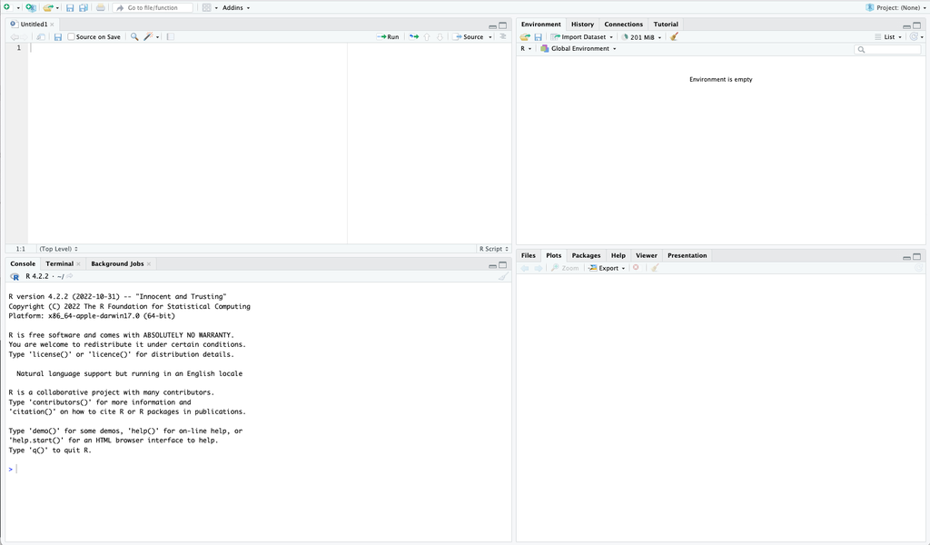

The RStudio interface is divided into 4 compartments:

1. The script file in the top left is where you type commands, run them, and save them for future use
2. The console in the bottom left is where R commands are run and the results shown
3. The environment in the top right is where the data and other variables that you have read into R will be shown
4. The window in the bottom right is where plots will be shown, and where help file information can be found

The last step of installation is to install some R extension packages. The easiest way to do this is by going to the “Tools” menu, then “Install Packages…” - you will see a small window pop up. We are going to install a package called “tidyverse”, so start typing the word tidyverse into the text bar in the middle, then click on the name when it appears. Then click on the install button.

You will start to see some things happen in the R console: R is downloading the relevant packages, and installing them for you. It has finished when you see text at the bottom that starts with “The downloaded binary packages are in …”.

### Setting up an R script file

To begin working in R, we first need to set up our R script and save it. Copy and paste the following 3 lines of R code from this file and paste it at the top of your empty R script file:

```r
### A script file to read lameness data, 2023-01-23
library("tidyverse")
library("readxl")
```

The first line is a comment - anything that starts with the # character is ignored by R. We write comments in code to help us understand what we were trying to do when we wrote the code; it is a good idea to get into the habit of using lots of comments! You can write whatever you want - try doing that now (for example, change the date in the first comment). The next two lines load the packages that we will need to use for this exercise.

Now we can save the file. To do this, just click on “File” then “Save”, and enter a sensible file name and location to save the file. If you are asked to “Choose Encoding” then select “UTF-8” from the options. We recommend saving the R script file in the same location as the data; here we are going to work with the dataset we created in the exercise for topic 1, so save the R script file in the same place as that data file is stored - if you need another copy you can download the solution file from [here](https://www.costmodds.org/teaching/voc_data_science/topic1/solution_topic_1.xlsx)

### Setting variables in R

The next step is to set our working directory. We need to do this so that R can find our Excel file when we ask it to read from it. To do this, use the “Session” menu and select “Set Working Directory” then “Choose Directory”, and navigate to the folder where you saved the Excel file with the data. Then click “Open”. You will see some text appear in the R console that might look like this (except that the directory names will be different):

```r
setwd("~/Documents/DataScience/ErasmusPlusCourse")
```

Copy and paste this text from the R console into your R script file (just under the comments you wrote at the top) - this means that R will automatically know which working directory to use next time you re-open RStudio.

Now copy/paste the following code into the bottom of your R script (changing the name of the file to match your Excel file, if necessary):

```r
filename <- "solution_topic_1.xlsx"
```

This command tells R to take the text string representing the file name of our Excel file, and assign it to a new variable called ‘filename’. The ‘<-’ is called the left-arrow operator, and can be understood as putting the object on the right-hand side of the arrow into the variable name on the left-hand side of the arrow. The object could be anything from a simple text string like this to a large dataset or even the results of a fitted model. We can also reverse the direction of the arrow to put the object on the left-hand side of the arrow into the variable name on the right-hand side:

```r
"solution_topic_1.xlsx" -> filename
```

There is no difference between these two commands as far as R is concerned, but for single-line commands like this the convention is to use the first option.

Now copy/paste the following code into the bottom of your R script, below the previous command:

```r
sheets <- excel_sheets(filename)
```

This command also creates a new variable (this time called ‘sheets’), but now the right hand side is a function call - we know that because of the parantheses ( and ). To see what this function does, click on the “Help” tab of the plots/help window in the bottom right of your screen, type excel_sheets into the search bar, and then hit enter to show the help file. The title “List all sheets in an excel spreadsheet” gives us a good description of what this function does, but you can read more details in the help file if you like. All functions in R have a corresponding help file, so if you ever see a function in R code and want to find out what it does, just search for it’s help file!

Now run the two lines of code by highlighting the two lines and clicking “Run”. Alternatively, you can place your curser on the first line and then click “Run” twice - you will see that each line is run, and the curser is automatically moved onto the next line. This is a handy way to run through your R script slowly (one line at a time).

After running these two lines, you should now see two things have appeared in the environment window under “Values”: the filename has been stored with the value we gave it, and a new variable called sheets has been created which contains all of the names of the sheets in our Excel file. To see the value of these variables we can type the name of the variable into the R console:

```r
sheets
```

You should see output like this:

```
##  [1] "metadata"         "tables"           "variables"        "farm_data"
##  [5] "visit_data"       "registry_animal"  "registry_calving" "registry_milk"
##  [9] "breed_lookup"     "gait_lookup"      "notes"
```

We can also use functions with the variables we have saved. For example, the class() function tells us what format the variable is stored in, and the length() function tells us how many elements a variable stores:

```r
class(sheets)
```

```
## [1] "character"
```

```r
length(sheets)
```

```
## [1] 11
```

This tells us that the sheets variable is a character vector of length 11, which is another way of saying that it is a collection of 11 text values.

### Reading data into R

Now we can actually start to read the dataset into R! To do that, we need to use the read_excel function, and to specify which sheet we want to read. It is usually a good idea to start with the lookup tables, as these often define the valid categories for our categorical variables:

```r
gait_lookup <- read_excel(filename, sheet="gait_lookup")
```

Now we have a new data frame in our envirnonemt window under “Data”: data frames are a special kind of variable that represent something very similar to a sheet in Excel. If you click on the name of the data frame, a new tab will open next to your R script file so that you can look at the data. Close the tab to return to your R script when you are done.

Working with data frames is a central feature of doing data science in R because they keep all of your related variables together in the same place, ensuring that each variable has the same number of rows. This approach also allows you to have multiple data frames each containing different variables, some of which might have the same name, and to combine (merge) them as needed later. Some functions work on whole data frames, for example summary(), ncol() and nrow():

```r
summary(gait_lookup)
```

```
##    GaitScore GaitDescription
##  Min.   :0   Length:5
##  1st Qu.:1   Class :character
##  Median :2   Mode  :character
##  Mean   :2
##  3rd Qu.:3
##  Max.   :4
```

```r
ncol(gait_lookup)
```

```
## [1] 2
```

```r
nrow(gait_lookup)
```

```
## [1] 5
```

However, we can also look at individual columns within the data frame by accessing them using a $ separator between the name of the data frame variable and the name of the column we want, for example:

```r
gait_lookup$GaitScore
```

```
## [1] 0 1 2 3 4
```

```r
length(gait_lookup$GaitScore)
```

```
## [1] 5
```

### Checking the formats of your data: factors

Before we can go any further, we need to check that R has correctly read the formats of each of the variables in our data - for example numbers are showing as numbers, dates are showing as dates, etc. To do this we can use the str() function:

```r
str(gait_lookup)
```

```
## tibble [5 × 2] (S3: tbl_df/tbl/data.frame)
##  $ GaitScore      : num [1:5] 0 1 2 3 4
##  $ GaitDescription: chr [1:5] "normal gait: the cow is not lame; the back is flat" "mildly lame: the back is slightly arched when walking" "moderately lame: the back is arched when both standing and walking, and the cow walks with short strides in one or more legs" "lame: the lame cow can still b…
```

This tells us that we have 5 rows of 2 columns, and gives us the name of each column along with the format that R has stored: usually either chr for character (text and ID variables), num for numbers, Factor for categorical variables, Date for dates, or POSIXct for date/times - but sometimes it might be something else! Note that date/times are much more difficult to work with than plain dates because we have to worry about time zones (including daylight savings time changes); if you don’t really need the times I would recommend using plain dates for that reason.

```r
gait_lookup$GaitScore <- factor(gait_lookup$GaitScore)
```

You can also specify the valid categories for categorical variables by specifying a levels argument to the factor function, for example:

```r
gait_lookup$GaitScore <- factor(gait_lookup$GaitScore, levels=c(0,1,2,3,4))
```

In this case, the variable we are changing into a factor is also our unique row identifier, so we know for certain that all of the valid categories are included exactly once. It is therefore not necessary to specify the levels unless you want to change the order in which the categories appear.

However, it is necessary to specify levels for categorical variables in data sheets, to make sure that you do not have any typos in the data. To help us do this when we get to reading the visit_data sheet, we can store a variable holding the valid gait scores now:

```r
gait_levels <- levels(gait_lookup$GaitScore)
gait_levels
```

```
## [1] "0" "1" "2" "3" "4"
```

This new variable gait_levels can be used like this:

```r
gait_lookup$GaitScore <- factor(gait_lookup$GaitScore, levels=gait_levels)
```

Note that it is necessary for factor columns in different data frames to have the same levels if you might want to combine the data frames using these factors later.

Now we have fixed the GaitScore column we can re-check the format of the data frame:

```r
str(gait_lookup)
```

```
## tibble [5 × 2] (S3: tbl_df/tbl/data.frame)
##  $ GaitScore      : Factor w/ 5 levels "0","1","2","3",..: 1 2 3 4 5
##  $ GaitDescription: chr [1:5] "normal gait: the cow is not lame; the back is flat" "mildly lame: the back is slightly arched when walking" "moderately lame: the back is arched when both standing and walking, and the cow walks with short strides in one or more legs" "lame: the lame cow can still b…
```

This looks OK, so we can move onto reading the next sheet.

### Checking the formats of your data: dates

Let’s skip ahead to reading one of the data sheets:

```r
farm_data <- read_excel(filename, sheet="farm_data")
str(farm_data)
```

```
## tibble [3 × 7] (S3: tbl_df/tbl/data.frame)
##  $ CHR       : chr [1:3] "9539" "9697" "9433"
##  $ Herd      : chr [1:3] "Herd_A" "Herd_B" "Herd_C"
##  $ HerdType  : chr [1:3] "Conventional" "Organic" "Conventional"
##  $ HerdSize  : num [1:3] 480 160 210
##  $ MilkSystem: chr [1:3] "Rotary parlour" "Herringbone parlour" "Robotic"
##  $ MilkFreq  : num [1:3] 3 2 3
##  $ VisitDate : chr [1:3] "2022-02-04" "2022-02-16" "2022-03-26"
```

This tells us that we have 3 rows of 7 columns, and this time there are a mixture of text (chr) and number (num) columns.

Again, some of these are not right: we should have HerdType and MilkSystem as factors, and VisitDate as a date, rather than text. The unique row identifier is CHR - we could turn this into a factor if we wanted to, but it is also OK to keep it as text because it is not really a categorical variable. But we should change the categorical variables into factors; we don’t have a lookup table for valid values, so we have to choose them based on what is in the data. This table only has 3 rows so we can easily see what they are, but for a bigger table it is easiest to use one of the following functions:

```r
unique(farm_data$HerdType)
```

```
## [1] "Conventional" "Organic"
```

```r
table(farm_data$HerdType)
```

```
##
## Conventional      Organic
##            2            1
```

Note the table() function by default does not show us how many missing values we have; to include a count of missing values (shown as ) we can add a useNA argument to the table function:

```r
table(farm_data$MilkSystem, useNA="always")
```

```
##
## Herringbone parlour             Robotic      Rotary parlour                <NA>
##                   1                   1                   1                   0
```

Now we just need to convert the factors in the data:

```r
farm_data$HerdType <- factor(farm_data$HerdType, levels=c("Conventional","Organic"))
farm_data$MilkSystem <- factor(farm_data$MilkSystem, levels=c("Rotary parlour","Herringbone parlour","Robotic"))
```

We also need to convert the VisitDate into a date, which we can do using the as.Date function:

```r
farm_data$VisitDate <- as.Date(farm_data$VisitDate)
```

The as.Date function can convert dates from either text or date/time formats, but if you are converting from text where the date is not in the standard YYYY-MM-DD format then you will need to tell as.Date how they are formatted using the format argument, for example:

```r
farm_data$VisitDate <- as.Date(farm_data$VisitDate, format="%d/%m/%Y")
```

Now we can re-check the format of our data:

```r
str(farm_data)
```

```
## tibble [3 × 7] (S3: tbl_df/tbl/data.frame)
##  $ CHR       : chr [1:3] "9539" "9697" "9433"
##  $ Herd      : chr [1:3] "Herd_A" "Herd_B" "Herd_C"
##  $ HerdType  : Factor w/ 2 levels "Conventional",..: 1 2 1
##  $ HerdSize  : num [1:3] 480 160 210
##  $ MilkSystem: Factor w/ 3 levels "Rotary parlour",..: 1 2 3
##  $ MilkFreq  : num [1:3] 3 2 3
##  $ VisitDate : Date[1:3], format: "2022-02-04" "2022-02-16" ...
```

For data sheets, we should always look at a summary of the data before moving on:

```r
summary(farm_data)
```

```
##      CHR                Herd                   HerdType    HerdSize
##  Length:3           Length:3           Conventional:2   Min.   :160.0
##  Class :character   Class :character   Organic     :1   1st Qu.:185.0
##  Mode  :character   Mode  :character                    Median :210.0
##                                                         Mean   :283.3
##                                                         3rd Qu.:345.0
##                                                         Max.   :480.0
##                MilkSystem    MilkFreq       VisitDate
##  Rotary parlour     :1    Min.   :2.000   Min.   :2022-02-04
##  Herringbone parlour:1    1st Qu.:2.500   1st Qu.:2022-02-10
##  Robotic            :1    Median :3.000   Median :2022-02-16
##                           Mean   :2.667   Mean   :2022-02-24
##                           3rd Qu.:3.000   3rd Qu.:2022-03-07
##                           Max.   :3.000   Max.   :2022-03-26
```

The type of summary statistic provided depends on the format of each variable: number and dates variables are both summarised as min, mean, max etc, and factors are summarised as an observed tally for each category. It is not possible to usefully summarise text. If any of the columns include missing data, then you will also see the number of missing observations counted at the bottom as “NA’s” (including for text variables). It is important to check that these summary statistics look sensible i.e. the range of number and date variables is sensible, you don’t have any unexpected categories for factors, and you don’t have any missing data where you weren’t expecting it.

### Some advice

Working with R coding is tricky when you get started, so try not to get frustrated if it is difficult at first. You will improve with a bit of practice, and hopefully you will soon get the hang of it! Here is some advice that might help!

- Copy and paste R code from working examples wherever possible. It is much easier to adapt R code that already works for another problem or dataset and simply change the data frame and/or variable name, than to write the R code from scratch every time.
- Pay attention to any red output (errors or warnings) in the R console. If you get errors when running your code, it is not a good idea to keep trying to run more code - you first need to work out why there is an error and fix it!
- Sometimes while writing code we can accidentally break the dataset we have in R, for example if we run a factor() command twice on the same variable. But don’t worry - we can always read it back from the original Excel file to undo any mistakes we made! If you see errors that you don’t understand when running code that looks right, it is often a good idea to try running the R script again all the way from the top.

## Excercise

Repeat the process shown above for the other tables in your data, i.e. breed_lookup, visit_data, registry_animal, registry_calving, and registry_milk. There is no need to import the description sheets or the notes sheet. Save the file regularly while you are working on it!

Once you have finished, make sure that your R script can be run without errors by clicking on the “Source” button (to the right of the “Run” button above the R script window). This runs all of the code from top to bottom in the R script file. Once you are happy, quit RStudio and then re-open RStudio and your R script file. Source the R script again, and make sure that you see all of the data frames appearing in the environment tab as expected.

Remember to keep hold of the finished R script, as you will need it for the exercise at the end of the next session!

## Feedback and acknowledgements

If you have any feedback or suggestions on this training material then please consider filling out [our brief survey](https://forms.gle/KDtwsygjJdE2azBk8)

Development of this training material was partly funded by the [Veterinary Online Collection](https://veterinary-online-collection.eu).

[Return to home page](https://www.costmodds.org/teaching/voc_data_science/)